# wrangle_report

## Reporting: wrangle_report

The wrangling process consists of

1. Gathering
2. Accessing
3. Cleaning

### Gathering

There were 3 datasets involved in this project

1. The twitter-archive-enhanced dataset
2. The image-prediction dataset
3. The tweet-json dataset

#### Gathering for the twitter-archive-enhanced dataset

This dataset was provided by the instructor for the wrangling course and I downloaded it directly from udacity servers. The dataset was a Comma Seperated Value file.

#### Gathering for the tweet-json dataset

The instruction received for gathering this dataset was to use the tweepy library which is an API for downloading insights you find useful from twitter. Unfortunately due to twitter not responding quickly to my request to access the neccessary information, we were given the option to download it from Udacity servers. I then used the request library to download this dataset. The dataset was a Javasript Object Notation file. After downloading the dataset, I extracted the id, retweet_count, favorite_count, lang columns to a new dataframe and stored its content in a new csv file called twitter-archive-enhanced-2.csv

### Accessing

Here I looked at the dataset both visually and programatically to understand its structure

The info() fuction of pandas ran on the twitter-archive-enhanced dataset produced the following results

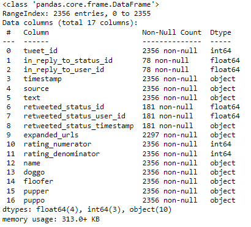

We can make some useful deductions from the results above.There are 17 columnns in this dataset with a supposed total of 2356 entries for each column but we can see that some columns have very few entries. eg.in_reply_to_status_id have only 78 out of 2356 entries. We can find some wrong datatypes for certain columns. Eg. is the timestamp column which have a datatype of object(string) instead of timestamp.

I also ran the info() function on the image-prediction dataset

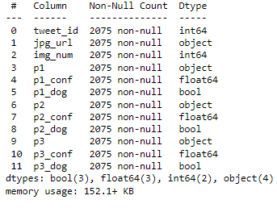

The image in the cell above depicts the results of running the info() function on the image-prediction dataset. Here, we can deduce that the dataset has 12 columns. It contains 3 different algorithms for predicting whether an image is a dog or not. For now we can see there are no missing values with each column having an entry of 2075

Lastly the info() function was ran on the twitter-archive-enhanced-2 dataset which produced the results below

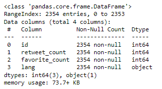

The dataset has 4 columns (we extrated these columns at the data gathering stage). It has 2354 entries or rows with non of the columns having null values.

### Cleaning

These are some of the quality and tidiness issues we encountered after thoroughly accessing the datasets

### Quality issues

1. The in_reply_to_status_id, in_reply_to_user_id, retweeted_status_id retweeted_status_user_id and retweeted_status_timestamp columns in the twitter-archive-enhanced dataset have more than 90% of its data been null values
2. Source of tweet embedded in the href tag in the twitter-archive-enhanced dataset.
3. Inconsistent rating_numerator amd rating_denominator values compared to what is in the text column.
4. Incorrect datatype for the ID columns in all 3 dataset
5. Incorrect datatype for the new rating_numerator and rating_denominator values
6. Incorrect datatype for lang column in enhance_df2 dataframe and timestamp in enhance_df
7. All three predictions in the image_prediction_df dataframe been false
8. Actual rating of each dog

### Tidiness issues

1. Dog stages in 4 columns instead of 1
2. All dataframes form one observation

#### Solving Issue 1

I dropped the in_reply_to_status_id, in_reply_to_user_id, retweeted_status_id, retweeted_status_user_id and retweeted_status_timestamp columns because their entries were not up to 10% of the total entries needed. The new dataframe will have now have the columns displayed below;

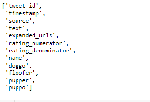

#### Solving Issue 2

The source of the tweet was in an href tag. I stripped the tags off with a regular expression leaving the actual content.

How the source was displayed '[Twitter for iPhone](http://twitter.com/download/iphone)' Below is the new display for the source column

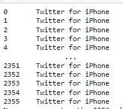

#### Solving Issue 3

The actual values for the rating_numerator and rating_denominator can be found in the text column. Since some of the original values given for these columns were said to be incorrect, I had to extract the new values from the text column using a regular expression. A snippet of the extraction code is found below

new_ratings = enhanced_df_clean.text.str.extract('((?:\d+\.)?\d+)\/(\d+)', expand=True)

After extraction, I appended the new values to the dataframe and dropped the rating_numerator and rating_denominator values. The columns now present is displayed in the cell below

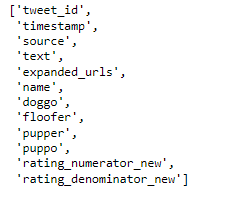

#### Solving Issue 4

Since we are not going to perform any mathematical operations on the id columns, it is best we convert its datatype to object. This I did and also change the column name 'id' in the twitter-archive_2 dataset to tweet_id to make it consistnt with the other two dataframes

#### Solving Issue 5

Our columns rating_numerator_new and rating_denominator_new came with the object datatype. For the sake of further analysis on this column, we change the datatype float.

#### Solving Issue 6

Another datatype isssue is the lang and timestamp columns in the twitter_archive_2 and twitter_archive dataset respectively. I changed the lang to category datatype and timestamp to dtae_time.

#### Solving Issue 7

If all the three algorithms return false, it means there is a high chance of the image tweeted not been a dog or even having a dog in it. These rows will not be very beneficial in our analysis so I dropped them from the image_prediction dataset

#### Solving Issue 9

The doggo,floofer,pupper,puppo columns in the enhanced_df dataset all depicts the stage of growth of the dog. The 4 dataset should be actually 1 column with its name as dog_stage. The datatype was then changed to category data type. Below is the display of the columns in the twitter_archive dataset after the dog_stage column is created and the other 4 is deleted.

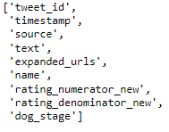

#### Solving Issue 10

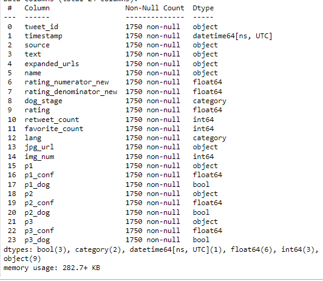